# Local minima in multistate capture-recapture models

## Model

We consider a state-space formulation of multistate capture-recapture model. We refer to [Gimenez et al. (2007). State-space modelling of data on marked individuals. Ecological Modelling 206: 431-438](https://dl.dropboxusercontent.com/u/23160641/my-pubs/Servantyetal2010Ecology.pdf) and [Servanty et al. (2010). Assessing whether mortality is additive using marked animals: a Bayesian state-space modeling approach. Ecology 91: 1916–1923](https://dl.dropboxusercontent.com/u/23160641/my-pubs/Gimenezetal2007EcologicalModelling.pdf) for the theory.

## Read in data

I use female roe deer data monitored over 20 years and provided by J.-M. Gaillard. Population in Trois Fontaine managed by ONCFS. Two states, with and without fawn.

```r
his <- matrix(c(0,0,0,0,0,0,0,0,0,0,0,0,0,0,0,0,0,0,2,2,1,
0,0,0,0,0,0,0,0,0,0,0,0,0,0,0,0,2,0,0,0,1,
0,0,0,0,0,0,0,0,0,0,0,0,0,0,0,1,0,0,0,0,1,
0,0,0,0,0,0,0,0,0,0,0,0,0,0,0,2,2,1,0,0,1,
0,0,0,0,0,0,0,0,0,0,0,0,0,0,0,2,2,0,0,2,1,
0,0,0,0,0,0,0,0,0,0,0,0,0,0,1,2,0,0,0,0,1,
0,0,0,0,0,0,0,0,0,0,0,0,0,1,1,2,2,0,1,1,1,
0,0,0,0,0,0,0,0,0,0,0,0,0,2,0,0,2,1,2,0,1,
0,0,0,0,0,0,0,0,0,0,0,0,0,2,2,2,2,1,1,1,1,
0,0,0,0,0,0,0,0,0,0,0,0,0,2,0,0,0,0,0,0,1,
0,0,0,0,0,0,0,0,0,0,0,0,0,2,2,0,0,0,0,0,1,
0,0,0,0,0,0,0,0,0,0,0,0,0,2,2,0,0,0,0,0,1,
0,0,0,0,0,0,0,0,0,0,0,0,2,2,0,2,1,2,0,0,1,
0,0,0,0,0,0,0,0,0,0,0,1,0,0,2,0,1,2,2,0,1,
0,0,0,0,0,0,0,0,0,0,0,1,2,0,0,0,0,0,0,0,1,
0,0,0,0,0,0,0,0,0,0,0,2,0,0,0,1,0,1,0,0,1,
0,0,0,0,0,0,0,0,0,0,0,2,0,0,0,2,2,1,0,0,1,
0,0,0,0,0,0,0,0,0,0,0,2,1,0,0,0,0,0,0,0,1,
0,0,0,0,0,0,0,0,0,0,0,2,1,2,0,1,1,1,0,0,1,
0,0,0,0,0,0,0,0,0,0,0,2,2,0,2,2,2,2,1,0,1,
0,0,0,0,0,0,0,0,0,0,0,2,2,2,2,0,0,0,0,0,1,
0,0,0,0,0,0,0,0,0,0,2,1,0,0,0,0,0,0,0,0,1,
0,0,0,0,0,0,0,0,0,0,2,0,0,0,0,0,0,0,0,0,1,
0,0,0,0,0,0,0,0,0,0,2,0,0,0,0,0,0,0,0,0,1,
0,0,0,0,0,0,0,0,0,0,2,0,0,0,2,2,0,1,1,0,1,
0,0,0,0,0,0,0,0,0,0,2,1,2,1,1,2,0,0,0,0,1,
0,0,0,0,0,0,0,0,0,0,2,2,2,1,0,2,2,2,0,0,1,
0,0,0,0,0,0,0,0,0,1,2,2,0,0,0,0,0,0,0,0,1,
0,0,0,0,0,0,0,0,0,2,0,0,0,0,0,0,0,0,0,0,1,
0,0,0,0,0,0,0,0,1,0,0,0,0,0,0,0,0,0,0,0,1,
0,0,0,0,0,0,0,0,2,0,2,2,0,0,0,0,0,1,0,0,1,
0,0,0,0,0,0,0,0,2,0,0,0,0,0,0,0,0,0,0,0,1,
0,0,0,0,0,0,0,1,0,0,0,0,0,0,0,0,0,0,0,0,1,
0,0,0,0,0,0,0,1,0,0,0,0,0,0,0,0,0,0,0,0,1,
0,0,0,0,0,0,0,1,0,0,2,2,0,2,0,0,0,0,0,0,1,
0,0,0,0,0,0,0,2,0,0,2,1,0,0,0,0,0,0,0,0,1,
0,0,0,0,0,0,0,2,1,1,0,2,0,0,0,0,0,0,0,0,1,
0,0,0,0,0,0,1,0,0,0,0,0,0,0,0,0,0,0,0,0,1,
0,0,0,0,0,0,1,0,0,0,0,0,0,0,0,0,0,0,0,0,1,
0,0,0,0,0,0,1,0,0,0,0,0,2,0,0,0,0,0,0,0,1,
0,0,0,0,0,0,2,2,0,0,0,0,0,0,0,0,0,0,0,0,1,
0,0,0,0,0,0,2,2,0,0,0,0,0,0,0,0,0,0,0,0,1,
0,0,0,0,0,0,2,2,0,2,2,0,0,2,0,2,0,0,0,0,1,
0,0,0,0,0,0,2,2,0,0,0,0,0,0,0,0,0,0,0,0,1,
0,0,0,0,0,0,2,2,0,0,0,1,0,2,0,0,0,0,0,0,1,
0,0,0,0,0,0,2,2,0,0,0,2,0,0,0,0,0,0,0,0,1,
0,0,0,0,0,1,1,1,0,0,1,2,0,0,0,0,0,0,0,0,1,
0,0,0,0,0,1,1,2,0,0,0,0,0,0,0,0,0,0,0,0,1,
0,0,0,0,0,1,1,2,0,0,0,0,0,0,0,0,0,0,0,0,1,
0,0,0,0,0,1,2,2,0,1,0,0,0,0,0,0,0,0,0,0,1,
0,0,0,0,0,2,1,2,0,0,2,2,0,0,0,0,0,0,0,0,1,
0,0,0,0,0,2,1,2,2,2,2,2,0,0,0,0,0,0,0,0,1,
0,0,0,0,0,2,2,0,0,0,0,0,0,0,0,0,0,0,0,0,1,
0,0,0,0,0,2,2,2,2,0,0,0,0,0,0,0,0,0,0,0,1,
0,0,0,0,1,0,0,0,0,0,0,0,0,0,0,0,0,0,0,0,1,
0,0,0,0,1,0,0,0,0,0,0,0,0,0,0,0,0,0,0,0,1,
0,0,0,0,2,0,2,0,2,1,0,0,0,2,0,0,0,0,0,0,1,
0,0,0,0,2,2,0,0,0,0,0,0,0,0,0,0,0,0,0,0,1,
0,0,0,0,2,2,2,2,0,0,0,0,0,0,0,0,0,0,0,0,1,
0,0,0,0,2,0,2,0,0,0,0,0,0,0,0,0,0,0,0,0,1,
0,0,0,0,2,0,2,0,0,2,2,0,0,0,0,0,0,0,0,0,1,
0,0,0,0,2,0,2,2,2,2,2,2,0,0,0,0,0,0,0,0,1,
0,0,0,2,0,0,0,0,0,0,0,0,0,0,0,0,0,0,0,0,1,
0,0,0,2,2,2,0,0,0,0,0,0,0,0,0,0,0,0,0,0,1,
0,0,0,2,2,0,2,2,0,2,0,0,0,0,0,0,0,0,0,0,1,
0,0,0,2,2,2,0,0,1,0,0,0,0,0,0,0,0,0,0,0,1,
0,0,0,2,2,2,1,0,0,0,0,0,0,0,0,0,0,0,0,0,1,
0,0,2,0,0,0,0,0,0,0,0,0,0,0,0,0,0,0,0,0,1,
0,0,2,2,2,1,2,0,0,0,2,2,0,1,0,0,0,0,0,0,1,
0,0,2,0,0,0,0,0,0,0,0,0,0,0,0,0,0,0,0,0,1,
0,0,2,0,0,0,0,0,0,0,0,0,0,0,0,0,0,0,0,0,1,
0,0,2,0,0,0,2,0,0,0,0,1,0,0,0,0,0,0,0,0,1,
0,0,2,2,0,0,0,0,0,0,0,0,0,0,0,0,0,0,0,0,1,
0,0,2,2,0,0,2,2,1,0,0,0,0,0,0,0,0,0,0,0,1,
0,0,2,2,2,2,2,0,0,0,0,0,0,0,0,0,0,0,0,0,1,
0,2,2,2,0,0,0,0,0,0,0,0,0,0,0,0,0,0,0,0,1,
0,2,2,2,2,2,0,0,0,0,0,0,0,0,0,0,0,0,0,0,1,
0,2,2,2,0,0,0,0,0,0,0,0,0,0,0,0,0,0,0,0,1,
0,2,2,2,2,2,2,2,0,0,2,2,0,1,0,0,0,0,0,0,1,
2,1,2,2,2,0,0,0,0,0,0,0,0,0,0,0,0,0,0,0,1),byrow=T,ncol=21)
```

## Frequentist Analysis with `Mark`

Let’s format the data to be analysed.

```r
his = his[,-ncol(his)] # remove last column, these are the counts
k = ncol(his) # nb of capture occasions
n = nrow(his) # nb of individuals
out = array(dim=n)
for (i in 1:n){
    y = (his[i,] > 0) * his[i,]
    out[i] = paste(y,collapse="")
}
capt.hist = data.frame(ch = out)
```

Load RMark package

```r
library(RMark)
```

Process data and create default design matrix

```r
mstrata.processed=process.data(capt.hist,model="Multistrata")
mstrata.ddl=make.design.data(mstrata.processed)
```

Define structure on parameters, all state dependent

```r
# survival probability
S.site = list(formula=~stratum)
# detection probability
p.site = list(formula=~stratum)
# transition probs
Psi.site = list(formula=~-1+stratum:tostratum)
```

Fit model

```r
mstrata.mod = mark(mstrata.processed,mstrata.ddl,model.parameters=list(S=S.site,p= p.site,Psi=Psi.site),output=FALSE,silent=T,delete=T)
```

Let’s have a look to the parameter estimates

```r
mstrata.mod$results$real[c(1:5,195),]
```

```
##                            estimate        se       lcl       ucl fixed
## S s1 g1 c1 a0 o1 t1       0.7894771 0.0407036 0.6988373 0.8583662
## S s2 g1 c1 a0 o1 t1       0.8624651 0.0484991 0.7377957 0.9332233
## p s1 g1 c1 a1 o1 t2       0.2503825 0.0381443 0.1831870 0.3322017
## p s2 g1 c1 a1 o1 t2       1.0000000 0.0000000 1.0000000 1.0000000
## Psi s1 to2 g1 c1 a0 o1 t1 0.3185984 0.0425212 0.2415652 0.4070139
## Psi s2 to1 g1 c1 a0 o1 t1 0.4814443 0.0457103 0.3933815 0.5706751
##                              note
## S s1 g1 c1 a0 o1 t1
## S s2 g1 c1 a0 o1 t1
## p s1 g1 c1 a1 o1 t2
## p s2 g1 c1 a1 o1 t2
## Psi s1 to2 g1 c1 a0 o1 t1
## Psi s2 to1 g1 c1 a0 o1 t1
```

Now let’s re-run the same model but changing the initial values

```r
nb_inits = 5 # five runs with diff inits
set.seed(3) # to reproduce the results
res_dev = rep(NA,nb_inits)
res = list()
for (i in 1:nb_inits){
    inits = rnorm(6,0,1)
    mstrata.sim = mark(mstrata.processed,mstrata.ddl,model.parameters=
    list(S=S.site,p= p.site,Psi=Psi.site),output=FALSE,silent=TRUE,delete=T,initial = inits)
    res_dev[i] = mstrata.sim$results$deviance
    res[[i]] = mstrata.sim$results
}
```

Display the deviance values

```r
res_dev
```

```
## [1] 674.9109 669.3424 669.3424 669.3424 674.9109
```

There seems to be a local minimum. Let’s have a look to the estimates corresponding to the global minimum

```r
res[[2]]$real[c(1:5,195),1:4]
```

```
##                            estimate           se           lcl       ucl
## S s1 g1 c1 a0 o1 t1       0.7894771 4.070360e-02  6.988371e-01 0.8583662
## S s2 g1 c1 a0 o1 t1       0.8624651 4.849920e-02  7.377954e-01 0.9332235
## p s1 g1 c1 a1 o1 t2       0.2503825 3.814430e-02  1.831870e-01 0.3322017
## p s2 g1 c1 a1 o1 t2       1.0000000 4.875491e-05 6.601044e-297 1.0000000
## Psi s1 to2 g1 c1 a0 o1 t1 0.3185984 4.252120e-02  2.415652e-01 0.4070140
## Psi s2 to1 g1 c1 a0 o1 t1 0.4814443 4.571040e-02  3.933814e-01 0.5706753
```

What about the estimates with a local minimum?

```r
res[[1]]$real[c(1:5,195),1:4]
```

```
##                            estimate        se       lcl       ucl
## S s1 g1 c1 a0 o1 t1       0.6927284 0.0688787 0.5445474 0.8095592
## S s2 g1 c1 a0 o1 t1       0.8360090 0.0221533 0.7878672 0.8749594
## p s1 g1 c1 a1 o1 t2       1.0000000 0.0000000 1.0000000 1.0000000
## p s2 g1 c1 a1 o1 t2       0.5358710 0.0358389 0.4653806 0.6049567
## Psi s1 to2 g1 c1 a0 o1 t1 0.7112866 0.0693975 0.5595388 0.8269254
## Psi s2 to1 g1 c1 a0 o1 t1 0.1324606 0.0212328 0.0960831 0.1798702
```

## Graphical examination

We use a graph of profile deviance to examine local minima. Let’s do it for survival first:

```r
fr = mstrata.ddl$S$stratum
ii = (fr==1)
phi.fix = as.numeric(row.names(mstrata.ddl$S[ii,]))

grid = seq(.6,0.8,0.01/2)
#length(grid)
dev = rep(NA,length(grid))
ind = 1
for (i in grid){
    S.fix = list(formula=~stratum,fixed=list(index=phi.fix,value=i)) # survival depends on states
    res.fix = mark(mstrata.processed,mstrata.ddl,model.parameters=list(S=S.fix,p=p.site,Psi=Psi.site),output = FALSE,delete=T,silent=T)
    dev[ind] = res.fix$results$deviance
    ind = ind + 1
}
dev_phi = dev
grid_phi = grid
```

Then for a transition

```r
fr = mstrata.ddl$Psi$stratum
to = mstrata.ddl$Psi$tostratum
ii = (fr==2 & to==1)
psi.fix = as.numeric(row.names(mstrata.ddl$Psi[ii,])) # careful not to define Psi.fix twice

grid = seq(.05,0.55,0.01)
#length(grid)
dev = rep(NA,length(grid))
ind = 1
for (i in grid){
    Psi.fix = list(formula=~-1+stratum:tostratum,fixed=list(index=psi.fix,value=i),link='logit')     # needs logit here, mlogit is a mess
    res.fix = mark(mstrata.processed,mstrata.ddl,model.parameters=list(S=S.site,p=p.site,Psi=Psi.fix),output = FALSE,delete=T,silent=T)
    dev[ind] = res.fix$results$deviance
    ind = ind + 1
}
dev_psi = dev
grid_psi = grid
```

Let’s visualize the results

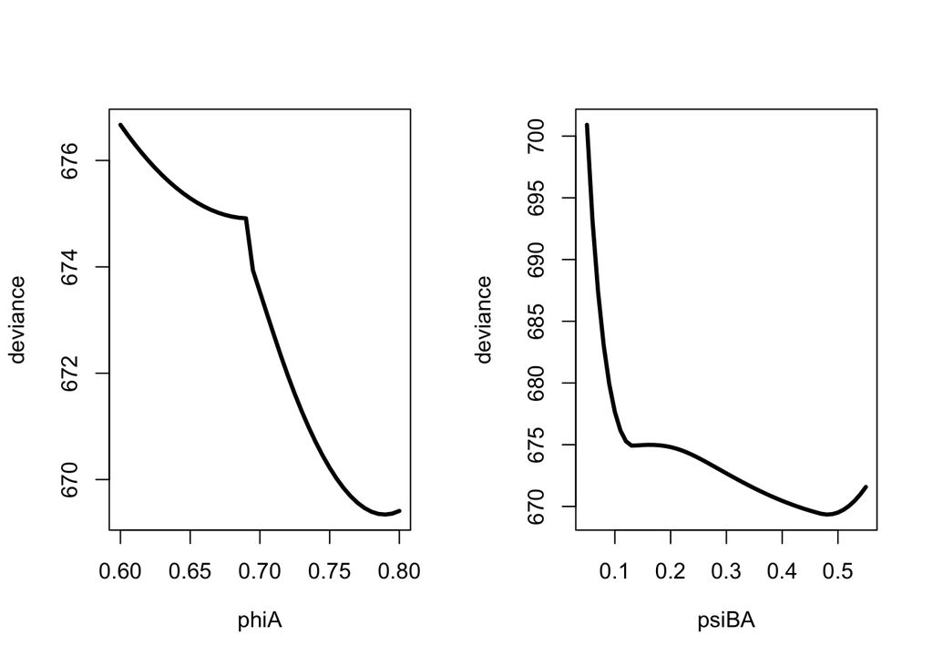

```r
par(mfrow=c(1,2))
plot(grid_phi,dev_phi,type='l',xlab=expression(phiA),ylab='deviance',col='black',lwd=3)
plot(grid_psi,dev_psi,type='l',xlab=expression(psiBA),ylab='deviance',col='black',lwd=3)
```

## Frequentist analysis with `ADMB`

Load `R2admb` package:

```r
library(R2admb)
```

Define model in ADMB language

```r
model <-
paste("
DATA_SECTION
 init_int k // Number of capture occations
 init_int nh // Number of encouter histories
 init_ivector e(1,nh) // Date of first capture
 init_imatrix data(1,nh,1,k) // Data matrix
 init_ivector eff(1,nh) // NUmber of individuals per capture history
 init_ivector garb(1,nh) // State of first capture
PARAMETER_SECTION
 init_bounded_number logit_pi(-20.0,20.0,1) // Prop
 init_bounded_number logit_phi1(-20.0,20.0,1) // Survival
 init_bounded_number logit_phi2(-20.0,20.0,1) // Survival
 init_bounded_number logit_det1(-20.0,20.0,1) // Capture probability
 init_bounded_number logit_det2(-20.0,20.0,1) // Capture probability
 init_bounded_number logit_psi1(-20.0,20.0,1) // Survival
 init_bounded_number logit_psi2(-20.0,20.0,1) // Survival
 objective_function_value g
 number pi
 number phi1
 number phi2
 number det1
 number det2
 number psi1
 number psi2
PROCEDURE_SECTION
 pi = mfexp(logit_pi);
 pi = pi/(1+pi);
 phi1 = mfexp(logit_phi1);
 phi1 = phi1/(1+phi1);
 phi2 = mfexp(logit_phi2);
 phi2 = phi2/(1+phi2);
 det1 = mfexp(logit_det1);
 det1 = det1/(1+det1);
 det2 = mfexp(logit_det2);
 det2 = det2/(1+det2);
 psi1 = mfexp(logit_psi1);
 psi1 = psi1/(1+psi1);
 psi2 = mfexp(logit_psi2);
 psi2 = psi2/(1+psi2);
 dvar_vector prop(1,3);
 prop(1) = pi; prop(2) = 1.0 - pi; prop(3) = 0.0;
 // B and BE are transposed:
 // we need to have obs in rows and states in columns
 // so that we can access rows of BE and B in the ADMB
 // way, e.g. BE(oe)
 dvar_matrix BE(1,3,1,3);
 BE(1,1) = 1.0;
 BE(1,2) = 0.0;
 BE(1,3) = 0.0;
 BE(2,1) = 0.0;
 BE(2,2) = 1.0;
 BE(2,3) = 0.0;
 BE(3,1) = 0.0;
 BE(3,2) = 0.0;
 BE(3,3) = 1.0;
 dvar_matrix B(1,3,1,3);
 B(1,1) = det1;
 B(1,2) = 0.0;
 B(1,3) = 0.0;
 B(2,1) = 0.0;
 B(2,2) = det2;
 B(2,3) = 0.0;
 B(3,1) = 1.0 - det1;
 B(3,2) = 1.0 - det2;
 B(3,3) = 1.0;
 dvar_matrix PHI(1,3,1,3);
 PHI(1,1) = phi1 * (1.0 - psi1);
 PHI(1,2) = phi1 * psi1;
 PHI(1,3) = 1.0 - phi1;
 PHI(2,1) = phi2 * psi2;
 PHI(2,2) = phi2 * (1.0 - psi2);
 PHI(2,3) = 1.0 - phi2;
 PHI(3,1) = 0.0;
 PHI(3,2) = 0.0;
 PHI(3,3) = 1.0;
 for(int i=1;i<=nh;i++){
    int ei = e(i); // date of marking
    int oe = garb(i); // initial obs
    ivector evennt = data(i);
    dvar_vector ALPHA = elem_prod(prop,BE(oe));
      for(int j=ei+1;j<=k;j++){
        ALPHA = elem_prod(ALPHA*PHI,B(evennt(j)));
        g -= log(sum(ALPHA))*eff(i);
    }
 }
")
writeLines(model,"model.tpl")
```

Specify where `ADMB` is

```r
setup_admb("/Applications/ADMBTerminal.app/admb")
```

```
## [1] "/Applications/ADMBTerminal.app/admb"
```

Prepare data

```r
dat = his
k = ncol(dat) # nb of capture occasions
nh = nrow(dat) # nb of individuals
eff = rep(1,nh)
fc <- NULL
init.state <- NULL
for (i in 1:nh){
  temp <- 1:k
  fc <- c(fc,min(which(dat[i,]!=0)))
  init.state <- c(init.state,dat[i,fc[i]])
}
dat[dat==0] <- 3 # replace 0's of non-detection by 3's
df = list(k=k,nh=nh,e=fc,data=dat,eff=eff,garb=init.state)
```

Fit model

```r
params <- list(logit_pi = 0,logit_phi1 = 0, logit_phi2 = 0, logit_det1 = 0, logit_det2 = 0,logit_psi1 = 0, logit_psi2 = 0) ## starting parameters
res <- do_admb('model', data=df, params = params,verbose=TRUE)
```

```
## writing data and parameter files ...
## compiling with args: '  -s ' ...
## compile output:
##   *** Parse: model.tpl tpl2cpp model || tpl2rem model  *** Compile: model.cpp c++ -c -std=c++14 -O3 -I. -I"/Applications/ADMBTerminal.app/admb/include" -I"/Applications/ADMBTerminal.app/admb/contrib/include" -omodel.obj model.cpp  *** Linking: model.obj  c++ -std=c++14 -O3 -omodel model.obj "/App…
## compile log:
##
## running compiled executable with args: '  '...
## Run output:
##
##
##
##
##
## Initial statistics: 7 variables; iteration 0; function evaluation 0; phase 1
## Function value   5.7642880e+03; maximum gradient component mag  -2.4747e+04
## Var   Value    Gradient   |Var   Value    Gradient   |Var   Value    Gradient
##   1  0.00000  8.24668e+03 |  2  0.00000 -8.15948e+03 |  3  0.00000 -2.47466e+04
##   4  0.00000  1.73534e+03 |  5  0.00000 -1.58105e+04 |  6  0.00000 -2.78031e+03
##   7  0.00000  1.47655e+04 |
##
## Intermediate statistics: 7 variables; iteration 10; function evaluation 23; phase 1
## Function value   4.3835920e+03; maximum gradient component mag  -1.7215e+03
## Var   Value    Gradient   |Var   Value    Gradient   |Var   Value    Gradient
##   1 -0.03892  1.08638e+02 |  2  0.00655 -1.72147e+03 |  3  0.04980 -1.54759e+03
##   4  0.11943 -4.76513e+01 |  5  0.00937 -1.08907e+03 |  6  0.03209 -1.16828e+01
##   7 -0.07117 -1.03375e+03 |
## 7 variables; iteration 20; function evaluation 34; phase 1
## Function value   4.3635513e+03; maximum gradient component mag   3.2371e+01
## Var   Value    Gradient   |Var   Value    Gradient   |Var   Value    Gradient
##   1 -0.03952  9.82803e+00 |  2  0.02340 -2.38586e+01 |  3  0.05344  2.27249e+01
##   4  0.10758 -4.05730e+00 |  5  0.01088  3.23706e+01 |  6  0.03328 -1.76291e+00
##   7 -0.06621  1.24650e+01 |
## 7 variables; iteration 30; function evaluation 44; phase 1
## Function value   4.3633833e+03; maximum gradient component mag  -2.3618e+00
## Var   Value    Gradient   |Var   Value    Gradient   |Var   Value    Gradient
##   1 -0.03958 -5.00217e-02 |  2  0.02348  8.68237e-02 |  3  0.05325 -7.43738e-01
##   4  0.24968 -7.12736e-02 |  5  0.01049 -2.36178e+00 |  6  0.03449  4.82657e-01
##   7 -0.06737 -2.34716e+00 |
## 7 variables; iteration 40; function evaluation 54; phase 1
## Function value   4.3633809e+03; maximum gradient component mag   3.5047e-01
```

[output cut: 14 more lines]

```
## Exit code = 1;  converg criter   1.0000e-04
## Var   Value    Gradient   |Var   Value    Gradient   |Var   Value    Gradient
##   1 -0.03958  3.33208e-06 |  2  0.02348 -2.85145e-05 |  3  0.05325  8.04471e-06
##   4  0.79797 -3.63062e-08 |  5  0.01049  4.80157e-05 |  6  0.03450  8.49209e-06
##   7 -0.06737 -4.25146e-06 |
## Estimating row 1 out of 7 for hessian
## Estimating row 2 out of 7 for hessian
## Estimating row 3 out of 7 for hessian
## Estimating row 4 out of 7 for hessian
## Estimating row 5 out of 7 for hessian
## Estimating row 6 out of 7 for hessian
## Estimating row 7 out of 7 for hessian
##
##
## reading output ...
```

Examine results

```r
summary(res)
```

```
## Model file: model
## Negative log-likelihood:  4363.4      AIC:  8740.8
## Coefficients:
##              Estimate Std. Error z value Pr(>|z|)
## logit_pi     -1.24265    0.07778 -15.976  < 2e-16 ***
## logit_phi1    0.73740    0.11008   6.699 2.11e-11 ***
## logit_phi2    1.67095    0.05572  29.991  < 2e-16 ***
## logit_det1   19.00137 4265.72729   0.004    0.996
## logit_det2    0.32960    0.04779   6.897 5.32e-12 ***
## logit_psi1    1.08333    0.12398   8.738  < 2e-16 ***
## logit_psi2   -2.11260    0.06470 -32.652  < 2e-16 ***
## ---
## Signif. codes:  0 '***' 0.001 '**' 0.01 '*' 0.05 '.' 0.1 ' ' 1
```

```r
res$coefficients
```

```
##   logit_pi logit_phi1 logit_phi2 logit_det1 logit_det2 logit_psi1
## -1.2426517  0.7374045  1.6709454 19.0013670  0.3295998  1.0833302
## logit_psi2
## -2.1126039
```

```r
1/(1+exp(-res$coefficients))
```

```
##   logit_pi logit_phi1 logit_phi2 logit_det1 logit_det2 logit_psi1
##  0.2239748  0.6764280  0.8417018  1.0000000  0.5816620  0.7471237
## logit_psi2
##  0.1078778
```

```r
res$se
```

```
##   logit_pi logit_phi1 logit_phi2 logit_det1 logit_det2 logit_psi1
## 7.7781e-02 1.1008e-01 5.5716e-02 4.2657e+03 4.7791e-02 1.2398e-01
## logit_psi2
## 6.4701e-02
```

Fit again model, changing initial values

```r
params <- list(logit_pi = -0.5,logit_phi1 = -0.5, logit_phi2 = -0.5, logit_det1 = -0.5, logit_det2 = -0.5,logit_psi1 = -0.5, logit_psi2 = -0.5) ## starting parameters
res <- do_admb('model', data=df, params = params,verbose=TRUE)
```

```
## writing data and parameter files ...
## compiling with args: '  -s ' ...
## compile output:
##   *** Parse: model.tpl tpl2cpp model || tpl2rem model  *** Compile: model.cpp c++ -c -std=c++14 -O3 -I. -I"/Applications/ADMBTerminal.app/admb/include" -I"/Applications/ADMBTerminal.app/admb/contrib/include" -omodel.obj model.cpp  *** Linking: model.obj  c++ -std=c++14 -O3 -omodel model.obj "/App…
## compile log:
##
## running compiled executable with args: '  '...
## Run output:
##
##
##
##
##
## Initial statistics: 7 variables; iteration 0; function evaluation 0; phase 1
## Function value   6.4529233e+03; maximum gradient component mag  -3.5199e+04
## Var   Value    Gradient   |Var   Value    Gradient   |Var   Value    Gradient
##   1 -0.01592  4.58658e+03 |  2 -0.01592 -1.05579e+04 |  3 -0.01592 -3.51995e+04
##   4 -0.01592 -2.53878e+03 |  5 -0.01592 -2.26527e+04 |  6 -0.01592 -3.67465e+03
##   7 -0.01592  1.06732e+04 |
##
## Intermediate statistics: 7 variables; iteration 10; function evaluation 22; phase 1
## Function value   4.3646460e+03; maximum gradient component mag  -6.2071e+02
## Var   Value    Gradient   |Var   Value    Gradient   |Var   Value    Gradient
##   1 -0.03941  2.75700e+01 |  2  0.02437 -4.34053e+01 |  3  0.05167 -6.20709e+02
##   4  0.06121 -5.98626e+00 |  5  0.01244  1.16247e+02 |  6  0.03010  1.98334e+01
##   7 -0.06235  1.00584e+02 |
## 7 variables; iteration 20; function evaluation 32; phase 1
## Function value   4.3636796e+03; maximum gradient component mag  -1.0840e+02
## Var   Value    Gradient   |Var   Value    Gradient   |Var   Value    Gradient
##   1 -0.03959 -9.07306e-01 |  2  0.02425  2.35537e+01 |  3  0.05348 -2.70984e+00
##   4  0.09191 -1.45604e+01 |  5  0.01075 -8.13619e+01 |  6  0.03288  1.17473e+01
##   7 -0.06611 -1.08402e+02 |
## 7 variables; iteration 30; function evaluation 42; phase 1
## Function value   4.3633826e+03; maximum gradient component mag  -2.2268e+00
## Var   Value    Gradient   |Var   Value    Gradient   |Var   Value    Gradient
##   1 -0.03958 -1.71801e-01 |  2  0.02347 -1.27635e+00 |  3  0.05324 -2.22680e+00
##   4  0.26293 -4.81314e-02 |  5  0.01050  1.03265e-01 |  6  0.03451  1.24823e+00
##   7 -0.06737 -1.58171e+00 |
## 7 variables; iteration 40; function evaluation 52; phase 1
## Function value   4.3633809e+03; maximum gradient component mag   7.6698e-03
```

[output cut: 14 more lines]

```
## Exit code = 1;  converg criter   1.0000e-04
## Var   Value    Gradient   |Var   Value    Gradient   |Var   Value    Gradient
##   1 -0.03958  3.83149e-06 |  2  0.02348  1.78164e-05 |  3  0.05325  3.21529e-05
##   4  0.80502 -2.97830e-10 |  5  0.01049 -1.95970e-05 |  6  0.03450 -1.25231e-05
##   7 -0.06737 -9.22151e-06 |
## Estimating row 1 out of 7 for hessian
## Estimating row 2 out of 7 for hessian
## Estimating row 3 out of 7 for hessian
## Estimating row 4 out of 7 for hessian
## Estimating row 5 out of 7 for hessian
## Estimating row 6 out of 7 for hessian
## Estimating row 7 out of 7 for hessian
##
##
## reading output ...
```

Examine results

```r
summary(res)
```

```
## Model file: model
## Negative log-likelihood:  4363.4      AIC:  8740.8
## Coefficients:
##              Estimate Std. Error z value Pr(>|z|)
## logit_pi     -1.24265    0.07778 -15.976  < 2e-16 ***
## logit_phi1    0.73740    0.11008   6.699 2.11e-11 ***
## logit_phi2    1.67095    0.05572  29.991  < 2e-16 ***
## logit_det1   19.06927 4257.85794   0.004    0.996
## logit_det2    0.32960    0.04779   6.897 5.32e-12 ***
## logit_psi1    1.08333    0.12398   8.738  < 2e-16 ***
## logit_psi2   -2.11260    0.06470 -32.652  < 2e-16 ***
## ---
## Signif. codes:  0 '***' 0.001 '**' 0.01 '*' 0.05 '.' 0.1 ' ' 1
```

```r
res$coefficients
```

```
##   logit_pi logit_phi1 logit_phi2 logit_det1 logit_det2 logit_psi1
## -1.2426517  0.7374045  1.6709454 19.0692710  0.3295998  1.0833302
## logit_psi2
## -2.1126039
```

```r
1/(1+exp(-res$coefficients))
```

```
##   logit_pi logit_phi1 logit_phi2 logit_det1 logit_det2 logit_psi1
##  0.2239748  0.6764280  0.8417018  1.0000000  0.5816620  0.7471237
## logit_psi2
##  0.1078778
```

```r
res$se
```

```
##   logit_pi logit_phi1 logit_phi2 logit_det1 logit_det2 logit_psi1
## 7.7781e-02 1.1008e-01 5.5716e-02 4.2579e+03 4.7791e-02 1.2398e-01
## logit_psi2
## 6.4701e-02
```

## Bayesian analysis with `Jags`

Let us get the occasion of first capture for each individual:

```r
get.first <- function(x) min(which(x!=0))
f <- apply(his, 1, get.first)
```

Recode the data such that 1 is seen alive in A (with fawn), 2 is seen alive in B (without fawn), 3 = not seen:

```r
his_recoded <- his
his_recoded[his_recoded==0] <- 3
```

Then we fit a multistate model:

```r
{
sink("state_on_survival.jags")
cat("
model {

# -------------------------------------------------
# Parameters:
# phiA: survival probability site A
# phiB: survival probability site B
# psiAB: movement probability from site A to site B
# psiBA: movement probability from site B to site A
# pA: recapture probability site A
# pB: recapture probability site B
# -------------------------------------------------
# States (S):
# 1 alive at A
# 2 alive at B
# 3 dead
# Observations (O):
# 1 seen at A
# 2 seen at B
# 3 not seen
# -------------------------------------------------

# Priors
   phiA ~ dunif(0, 1)
   phiB ~ dunif(0, 1)
   psiAB ~ dunif(0, 1)
   psiBA ~ dunif(0, 1)
   pA ~ dunif(0, 1)
   pB ~ dunif(0, 1)

# Define state-transition and observation matrices
for (i in 1:nind){
   # Define probabilities of state S(t+1) given S(t)
   for (t in f[i]:(n.occasions-1)){
      ps[1,i,t,1] <- phiA * (1-psiAB)
      ps[1,i,t,2] <- phiA * psiAB
      ps[1,i,t,3] <- 1-phiA
      ps[2,i,t,1] <- phiB * psiBA
      ps[2,i,t,2] <- phiB * (1-psiBA)
      ps[2,i,t,3] <- 1-phiB
      ps[3,i,t,1] <- 0
      ps[3,i,t,2] <- 0
      ps[3,i,t,3] <- 1

      # Define probabilities of O(t) given S(t)
      po[1,i,t,1] <- pA
      po[1,i,t,2] <- 0
      po[1,i,t,3] <- 1-pA
      po[2,i,t,1] <- 0
      po[2,i,t,2] <- pB
      po[2,i,t,3] <- 1-pB
      po[3,i,t,1] <- 0
      po[3,i,t,2] <- 0
      po[3,i,t,3] <- 1
      } #t
   } #i

# Likelihood
for (i in 1:nind){
   # Define latent state at first capture
   z[i,f[i]] <- y[i,f[i]]
   for (t in (f[i]+1):n.occasions){
      # State process: draw S(t) given S(t-1)
      z[i,t] ~ dcat(ps[z[i,t-1], i, t-1,])
      # Observation process: draw O(t) given S(t)
      y[i,t] ~ dcat(po[z[i,t], i, t-1,])
      } #t
   } #i
}
",fill = TRUE)
sink()
}
```

Function to create known latent states z

```r
known.state.ms <- function(ms, notseen){
   # notseen: label for ënot seení
   state <- ms
   state[state==notseen] <- NA
   for (i in 1:dim(ms)[1]){
      m <- min(which(!is.na(state[i,])))
      state[i,m] <- NA
      }
   return(state)
   }
```

Function to create initial values for unknown z

```r
ms.init.z <- function(ch, f){
   for (i in 1:dim(ch)[1]){ch[i,1:f[i]] <- NA}
   states <- max(ch, na.rm = TRUE)
   known.states <- 1:(states-1)
   v <- which(ch==states)
   ch[-v] <- NA
   ch[v] <- sample(known.states, length(v), replace = TRUE)
   return(ch)
   }
```

Create a list of data

```r
jags.data <- list(y = his_recoded, f = f, n.occasions = dim(his_recoded)[2], nind = dim(his_recoded)[1], z = known.state.ms(his_recoded, 3))
```

Initial values

```r
inits <- function(){list(phiA = runif(1, 0, 1), psiAB = runif(1, 0, 1), pA = runif(1, 0, 1), z = ms.init.z(his_recoded, f))}
```

Parameters to be monitored

```r
parameters <- c("phiA","phiB", "psiAB", "psiBA", "pA", "pB")
```

MCMC settings

```r
ni <- 5000 # nb iter
nt <- 6 # thinning
nb <- 1000 # burn-in
nc <- 2 # nb chains
```

Call JAGS from R

```r
library(R2jags)
ms <- jags(jags.data, inits, parameters, "state_on_survival.jags", n.chains = nc, n.thin = nt, n.iter = ni, n.burnin = nb)
```

```
## module glm loaded
```

```r
print(ms, digits = 3)
```

```
## Inference for Bugs model at "state_on_survival.jags", fit using jags,
##  2 chains, each with 5000 iterations (first 1000 discarded), n.thin = 6
##  n.sims = 1334 iterations saved
##          mu.vect sd.vect    2.5%     25%     50%     75%   97.5%  Rhat
## pA         0.335   0.139   0.202   0.256   0.293   0.353   0.779 1.019
## pB         0.842   0.126   0.545   0.765   0.872   0.944   0.995 1.026
## phiA       0.769   0.051   0.657   0.741   0.773   0.805   0.853 1.002
## phiB       0.856   0.040   0.783   0.829   0.854   0.882   0.939 1.005
## psiAB      0.389   0.099   0.260   0.327   0.364   0.425   0.671 1.017
## psiBA      0.391   0.096   0.161   0.340   0.412   0.462   0.529 1.025
## deviance 649.793  43.561 567.810 616.549 650.741 684.022 724.738 1.028
##          n.eff
## pA          82
## pB          62
## phiA      1300
## phiB       390
## psiAB       96
## psiBA       64
## deviance    60
##
## For each parameter, n.eff is a crude measure of effective sample size,
## and Rhat is the potential scale reduction factor (at convergence, Rhat=1).
##
## DIC info (using the rule, pD = var(deviance)/2)
## pD = 933.6 and DIC = 1583.4
## DIC is an estimate of expected predictive error (lower deviance is better).
```

Plot of the transition to illustrate local minimum

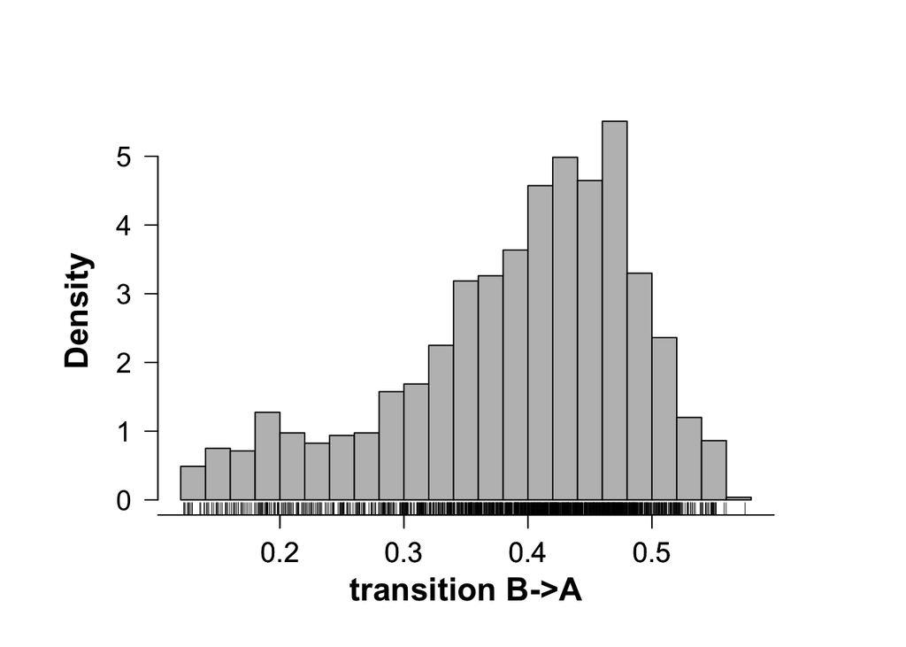

```r
par(cex.main = 1.5, mar = c(5, 6, 4, 5) + 0.1, mgp = c(3.5, 1, 0), cex.lab = 1.5 , font.lab = 2, cex.axis = 1.3, bty = "n", las = 1)
h <- hist(ms$BUGSoutput$sims.matrix[,7],breaks=20,freq=F,main="",xlab="",ylab="",col="gray")
axis(1, seq(0, .60, by = .1))
axis(2, labels = FALSE, lwd.ticks = 0)
rug(jitter(ms$BUGSoutput$sims.matrix[,7]))
mtext("transition B->A", side = 1, line = 2.5, cex = 1.5, font = 2)
mtext("Density", side = 2, line = 2.5, cex = 1.5, font = 2, las = 0)
```

## Bayesian analysis with `Stan`

```r
# https://github.com/stan-dev/example-models/tree/master/BPA
library(rstan)
rstan_options(auto_write = TRUE)
options(mc.cores = parallel::detectCores())
set.seed(123)
```

Data

```r
dat = list(y=his_recoded,n_occasions=k,nind=n)
```

Model

```r
{
sink("mstate.stan")
cat("
// -------------------------------------------------
// States (S):
// 1 alive at A
// 2 alive at B
// 3 dead
// Observations (O):
// 1 seen at A
// 2 seen at B
// 3 not seen
// -------------------------------------------------

functions {
  /**
   * Return an integer value denoting occasion of first capture.
   * This function is derived from Stan Modeling Language
   * User's Guide and Reference Manual.
   *
   * @param y         Observed values
   * @return Occasion of first capture
   */
  int first_capture(int[] y_i) {
    for (k in 1:size(y_i))
      if (y_i[k] != 3)
        return k;
    return 0;
  }
}

data {
  int<lower=0> nind;
  int<lower=0> n_occasions;
  int<lower=1,upper=3> y[nind, n_occasions];
}

transformed data {
  int<lower=0> n_occ_minus_1;
  int<lower=0,upper=n_occasions> first[nind];

  n_occ_minus_1 = n_occasions - 1;
  for (i in 1:nind)
    first[i] = first_capture(y[i]);
}

parameters {
  real<lower=0,upper=1> mean_phi[2]; // Mean state-spec. survival
  real<lower=0,upper=1> mean_psi[2]; // Mean transitions
  real<lower=0,upper=1> mean_p[2];   // Mean state-spec. recapture
}

transformed parameters {
  vector<lower=0,upper=1>[n_occ_minus_1] phiA;  // Survival prob. at site A
  vector<lower=0,upper=1>[n_occ_minus_1] phiB;  // Survival prob. at site B
  vector<lower=0,upper=1>[n_occ_minus_1] psiAB; // Movement prob. from site A to site B
  vector<lower=0,upper=1>[n_occ_minus_1] psiBA; // Movement prob. from site B to site A
  vector<lower=0,upper=1>[n_occ_minus_1] pA;    // Recapture prob. at site A
  vector<lower=0,upper=1>[n_occ_minus_1] pB;    // Recapture prob. at site B
  simplex[3] ps[3, nind, n_occ_minus_1];
  simplex[3] po[3, nind, n_occ_minus_1];

  // Constraints
  for (t in 1:n_occ_minus_1) {
    phiA[t] = mean_phi[1];
    phiB[t] = mean_phi[2];
    psiAB[t] = mean_psi[1];
    psiBA[t] = mean_psi[2];
    pA[t] = mean_p[1];
    pB[t] = mean_p[2];
  }

  // Define state-transition and observation matrices
  for (i in 1:nind) {
    // Define probabilities of state S(t+1) given S(t)
    for (t in 1:(n_occasions - 1)) {
      ps[1, i, t, 1] = phiA[t] * (1.0 - psiAB[t]);
      ps[1, i, t, 2] = phiA[t] * psiAB[t];
      ps[1, i, t, 3] = 1.0 - phiA[t];
      ps[2, i, t, 1] = phiB[t] * psiBA[t];
      ps[2, i, t, 2] = phiB[t] * (1 - psiBA[t]);
      ps[2, i, t, 3] = 1.0 - phiB[t];
      ps[3, i, t, 1] = 0.0;
      ps[3, i, t, 2] = 0.0;
      ps[3, i, t, 3] = 1.0;

      // Define probabilities of O(t) given S(t)
      po[1, i, t, 1] = pA[t];
      po[1, i, t, 2] = 0.0;
      po[1, i, t, 3] = 1.0 - pA[t];
      po[2, i, t, 1] = 0.0;
      po[2, i, t, 2] = pB[t];
      po[2, i, t, 3] = 1.0 - pB[t];
      po[3, i, t, 1] = 0.0;
      po[3, i, t, 2] = 0.0;
      po[3, i, t, 3] = 1.0;
    }
  }
}

model {
  real acc[3];
  vector[3] gamma[n_occasions];

  // Priors
  // Uniform priors are implicitly defined.
  //  mean_phi ~ uniform(0, 1);
  //  mean_psi ~ uniform(0, 1);
  //  mean_p ~ uniform(0, 1);

  // Likelihood
  // Forward algorithm derived from Stan Modeling Language
  // User's Guide and Reference Manual
  for (i in 1:nind) {
    if (first[i] > 0) {
      for (k in 1:3)
        gamma[first[i], k] = (k == y[i, first[i]]);

      for (t in (first[i] + 1):n_occasions) {
        for (k in 1:3) {
          for (j in 1:3)
            acc[j] = gamma[t - 1, j] * ps[j, i, t - 1, k]
                    * po[k, i, t - 1, y[i, t]];
          gamma[t, k] = sum(acc);
        }
      }
      target += log(sum(gamma[n_occasions]));
    }
  }
}
",fill = TRUE)
sink()
}
```

Initial values

```r
inits <- function() list(mean_phi = runif(2, 0, 1),
                         mean_psi = runif(2, 0, 1),
                         mean_p = runif(2, 0, 1))
```

Parameters monitored

```r
params <- c("mean_phi", "mean_psi", "mean_p")
```

MCMC settings

```r
ni <- 5000
nt <- 6
nb <- 1000
nc <- 2
```

Call Stan from R

```r
ms <- stan("mstate.stan",
           data = dat, init = inits, pars = params,
           chains = nc, iter = ni, warmup = nb, thin = nt,
           seed = 1,
           open_progress = FALSE)
```

[output not shown]

```r
print(ms, digits = 3)
```

```
## Inference for Stan model: mstate.
## 2 chains, each with iter=5000; warmup=1000; thin=6;
## post-warmup draws per chain=667, total post-warmup draws=1334.
##
##                 mean se_mean    sd     2.5%      25%      50%      75%
## mean_phi[1]    0.756   0.016 0.059    0.618    0.723    0.763    0.798
## mean_phi[2]    0.852   0.002 0.037    0.788    0.828    0.850    0.873
## mean_psi[1]    0.437   0.045 0.129    0.270    0.343    0.398    0.509
## mean_psi[2]    0.341   0.039 0.114    0.140    0.252    0.357    0.431
## mean_p[1]      0.415   0.083 0.204    0.211    0.278    0.331    0.476
## mean_p[2]      0.777   0.046 0.144    0.523    0.656    0.794    0.898
## lp__        -438.631   0.332 1.920 -443.493 -439.662 -438.203 -437.213
##                97.5% n_eff  Rhat
## mean_phi[1]    0.849    14 1.091
## mean_phi[2]    0.935   538 1.018
## mean_psi[1]    0.739     8 1.277
## mean_psi[2]    0.529     9 1.206
## mean_p[1]      0.980     6 1.386
## mean_p[2]      0.991    10 1.186
## lp__        -435.983    33 1.048
##
## Samples were drawn using NUTS(diag_e) at Mon May  8 15:37:50 2017.
## For each parameter, n_eff is a crude measure of effective sample size,
## and Rhat is the potential scale reduction factor on split chains (at
## convergence, Rhat=1).
```

Plot of the transition to illustrate local minimum

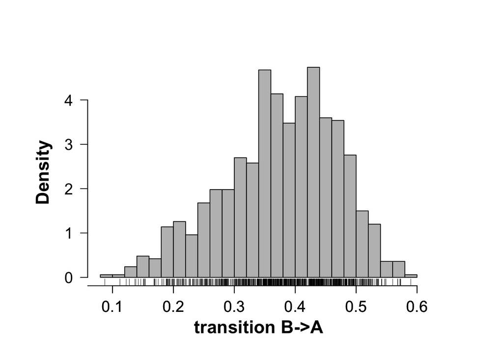

```r
par(cex.main = 1.5, mar = c(5, 6, 4, 5) + 0.1, mgp = c(3.5, 1, 0), cex.lab = 1.5 , font.lab = 2, cex.axis = 1.3, bty = "n", las = 1)
h <- hist(ms@sim$samples[[1]]$`mean_psi[2]`,breaks=20,freq=F,main="",xlab="",ylab="",col="gray")
axis(1, seq(0, .60, by = .1))
axis(2, labels = FALSE, lwd.ticks = 0)
rug(jitter(ms@sim$samples[[1]]$`mean_psi[2]`))
mtext("transition B->A", side = 1, line = 2.5, cex = 1.5, font = 2)
mtext("Density", side = 2, line = 2.5, cex = 1.5, font = 2, las = 0)
```